# Project_2

Splitting the data into training and test sets

```r
set.seed(101)
s <- sample(length(df$teff) , round(0.7*length(df$teff)))
df.train <- df[s,]
df.test <- df[-s,]
```

The dataset is split into training and test sets by selecting 70 % of the rows for training and the rest 30% for testing the model performance.

Linear Regression Model

```r
lm.out <- lm(teff ~ ., data = df.train)
summary(lm.out)
```

```
##
## Call:
## lm(formula = teff ~ ., data = df.train)
##
## Residuals:
##     Min      1Q  Median      3Q     Max
## -1829.5  -227.3   -65.8   114.6  3852.0
##
## Coefficients:
##               Estimate Std. Error t value Pr(>|t|)
## (Intercept)  1.389e+04  1.435e+02  96.817  < 2e-16 ***
## ra_x        -3.713e-01  6.148e-02  -6.039 1.63e-09 ***
## dec_x        4.039e+00  2.657e-01  15.202  < 2e-16 ***
## parallax    -1.862e+02  1.223e+01 -15.228  < 2e-16 ***
## pmra        -2.519e-01  3.474e-01  -0.725   0.4685
## pmdec        1.716e+00  3.934e-01   4.361 1.31e-05 ***
## g_mag       -6.704e+02  3.936e+02  -1.703   0.0885 .
## b_mag        6.516e+03  1.993e+02  32.698  < 2e-16 ***
## r_mag       -5.898e+03  3.510e+02 -16.803  < 2e-16 ***
## br_col      -2.100e+04  5.100e+02 -41.175  < 2e-16 ***
## L            5.114e-01  8.609e-02   5.941 2.97e-09 ***
## B           -3.890e+00  1.671e-01 -23.286  < 2e-16 ***
## ---
## Signif. codes:  0 '***' 0.001 '**' 0.01 '*' 0.05 '.' 0.1 ' ' 1
##
## Residual standard error: 404.1 on 6985 degrees of freedom
## Multiple R-squared:  0.7291, Adjusted R-squared:  0.7287
## F-statistic:  1709 on 11 and 6985 DF,  p-value: < 2.2e-16
```

Overall, the model appears to fit the data quite well, explaining a substantial amount of variability in the response variable with a relatively low residual standard error. The strong significance indicated by the F-statistic and the p-value suggests that the predictors used in the model have a meaningful relationship with the response variable.

Mean Square Error

```r
y.hat = predict(lm.out, newdata = df.test)
# valid_idx <- !is.na(y.hat) & !is.na(df.test$teff)
# mse <- mean((df.test$teff[valid_idx] - y.hat[valid_idx])^2)
mse <- mean((df.test$teff - y.hat)^2)
residuals <- df.test$teff - y.hat
print(mse)
```

```
## [1] 172450
```

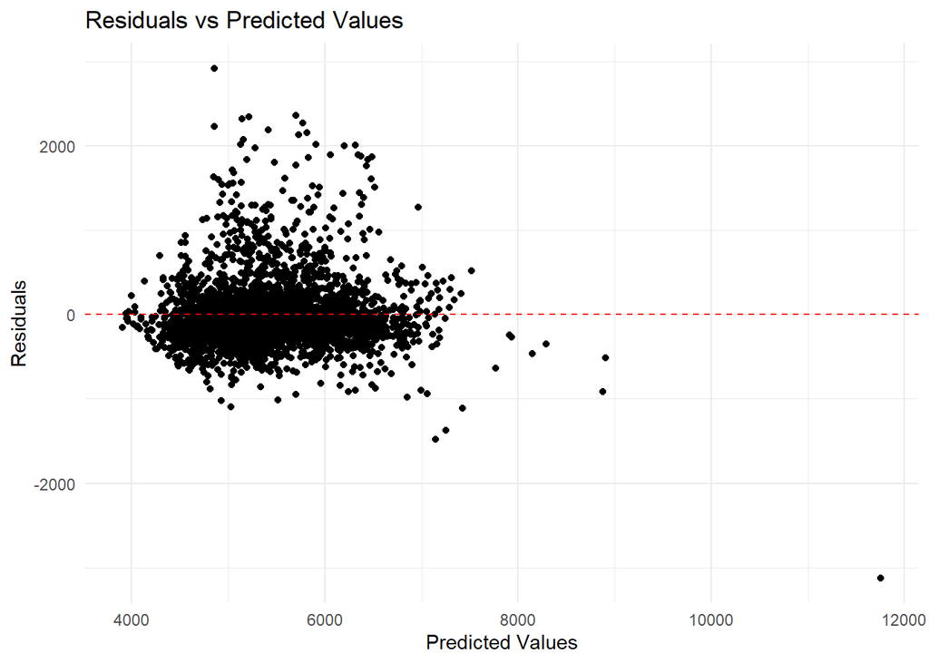

```r
# Residual Plot
ggplot(data = data.frame(y.hat, residuals), aes(x = y.hat, y = residuals)) +
  geom_point() +
  geom_hline(yintercept = 0, linetype = "dashed", color = "red") +
  labs(title = "Residuals vs Predicted Values", x = "Predicted Values", y = "Residuals") +
  theme_minimal()
```

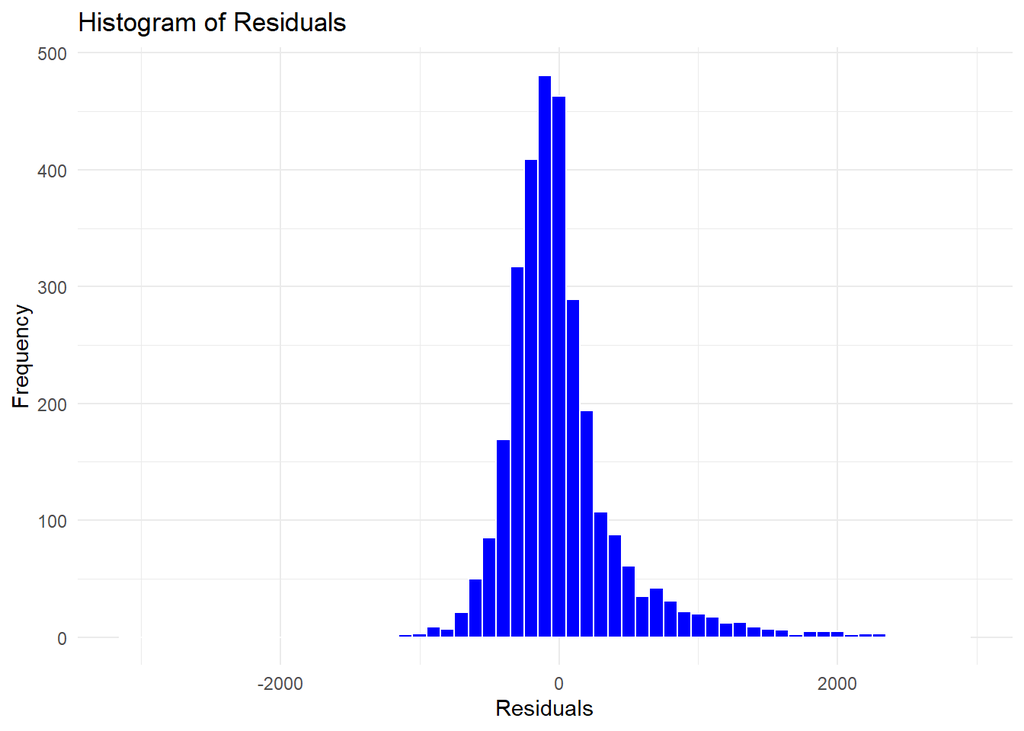

```r
# Histogram of residuals to check normality
ggplot(data = data.frame(residuals), aes(x = residuals)) +
  geom_histogram(binwidth = 100, fill = "blue", color = "white") +
  labs(title = "Histogram of Residuals", x = "Residuals", y = "Frequency") +
  theme_minimal()
```

The MSE of 172450 indicates a significant average squared difference between the actual values and the predicted values. This suggests that, while the model captures some trends in the data, there may still be room for improvement in its predictive accuracy.

Root mean square error

```r
rmse <- sqrt(mse)
print(rmse)
```

```
## [1] 415.271
```

Diagnostic Plot

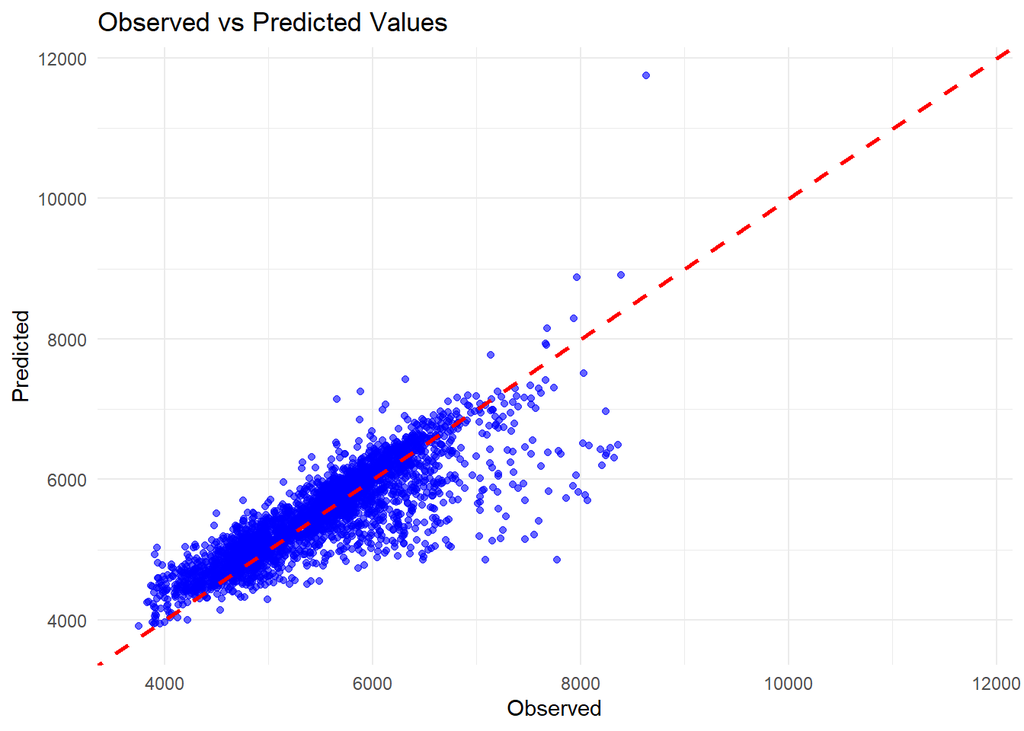

```r
df_plot <- data.frame(
  Observed = df.test$teff,
  Predicted = y.hat
)

axis_limits <- range(c(df_plot$Observed, df_plot$Predicted))

# Plot: Observed vs Predicted with a diagonal line
ggplot(df_plot, aes(x = Observed, y = Predicted)) +
  geom_point(alpha = 0.6, color = "blue") +  # Points for each observation
  geom_abline(slope = 1, intercept = 0, color = "red", linetype = "dashed", linewidth = 1) +  # Diagonal line
  xlim(axis_limits) + ylim(axis_limits) +  # Same limits for both axes
  labs(title = "Observed vs Predicted Values", x = "Observed", y = "Predicted") +
  theme_minimal()
```

The points clustering closely around the red dashed line (which represents the line of perfect prediction) suggest that your model’s predictions are generally accurate. When observed values are close to the predicted values, it indicates a good fit. The slight scattering of points around the diagonal line suggests that while the predictions are mostly accurate, there are still some discrepancies. This indicates variability in how well the model predicts certain observations, which aligns with your previous RMSE and residual analysis findings. The slight scattering of points around the diagonal line suggests that while your predictions are mostly accurate, there are still some discrepancies. This indicates variability in how well the model predicts certain observations, which aligns with your previous RMSE and residual analysis findings.

Check for multicollinearity using Variance Inflation Factor

```r
suppressMessages(library(car))
reduced_df <- df.train
lm.out <- lm(teff~.,data=reduced_df)
vif(lm.out)
```

```
##         ra_x        dec_x     parallax         pmra        pmdec        g_mag
##     1.551199     1.613032     1.326558     1.129252     1.117549 17955.152057
##        b_mag        r_mag       br_col            L            B
##  4790.170028 13897.434074   186.675009     1.815705     1.522496
```

The majority of some predictors (e.g., ra_x, dec_x, parallax, pmra, pmdec, L, B) have VIF values well below 10, indicating that multicollinearity is not a concern for these variables. However, there are extremely high VIF values for g_mag, b_mag, r_mag, and br_col, suggesting significant multicollinearity among these variables. Specifically: g_mag has a VIF of 17955.152, indicating severe multicollinearity. b_mag (VIF of 4790.170), r_mag (VIF of 13897.434), and br_col (VIF of 186.675) also indicate substantial multicollinearity.

Best Subset Selection

```r
library(dplyr)
library(bestglm)
set.seed(101)

# Ensure 'y' is numeric after renaming
df.renamed <- df %>% rename(y = teff)
df.renamed$y <- as.numeric(df.renamed$y)  # Ensure y is numeric

# Split the data into training and test sets
s <- sample(length(df.renamed$y), round(0.7 * length(df.renamed$y)))
df.train <- df.renamed[s, ]
df.test <- df.renamed[-s, ]
df.train <- na.omit(df.train)
df.test <- na.omit(df.test)

# Fit the full linear model
lm.out <- lm(y ~ ., data = df.train)

# Compute the MSE for the full model
mse.full <- mean((predict(lm.out, newdata = df.test) - df.test$y) ^ 2)  # df.test$y, not df.test$teff
print(paste("MSE of the full model:", mse.full))
```

```
## [1] "MSE of the full model: 172450.042961897"
```

```r
# Perform best subset selection using bestglm
bg.bic <- bestglm(df.train, family = gaussian, IC = "BIC")
bg.bic$BestModel
```

```
##
## Call:
## lm(formula = y ~ ., data = data.frame(Xy[, c(bestset[-1], FALSE),
##     drop = FALSE], y = y))
##
## Coefficients:
## (Intercept)         ra_x        dec_x         pmra        g_mag        b_mag
##   1.202e+04   -3.341e-01    4.511e+00   -2.507e-01   -6.795e+03    6.796e+03
##      br_col            L          y.1
##  -1.453e+04    5.445e-01   -4.263e+00
```

```r
bg.aic <- bestglm(df.train, family = gaussian, IC = "AIC")
bg.aic$BestModel
```

```
##
## Call:
## lm(formula = y ~ ., data = data.frame(Xy[, c(bestset[-1], FALSE),
##     drop = FALSE], y = y))
##
## Coefficients:
## (Intercept)         ra_x        dec_x         pmra        g_mag        b_mag
##   1.202e+04   -3.341e-01    4.511e+00   -2.507e-01   -6.795e+03    6.796e+03
##      br_col            L          y.1
##  -1.453e+04    5.445e-01   -4.263e+00
```

```r
# Number of predictors in BIC-selected model (excluding intercept)
bic_predictors <- length(coef(bg.bic$BestModel)) - 1
print(bic_predictors)
```

```
## [1] 8
```

```r
# Number of predictors in AIC-selected model (excluding intercept)
aic_predictors <- length(coef(bg.aic$BestModel)) - 1
print(aic_predictors)
```

```
## [1] 8
```

```r
#BSS MSE
bic_mse <- mean((df.test$y - bic_predictors)^2)
print(bic_mse)
```

```
## [1] 30905852
```

PCA

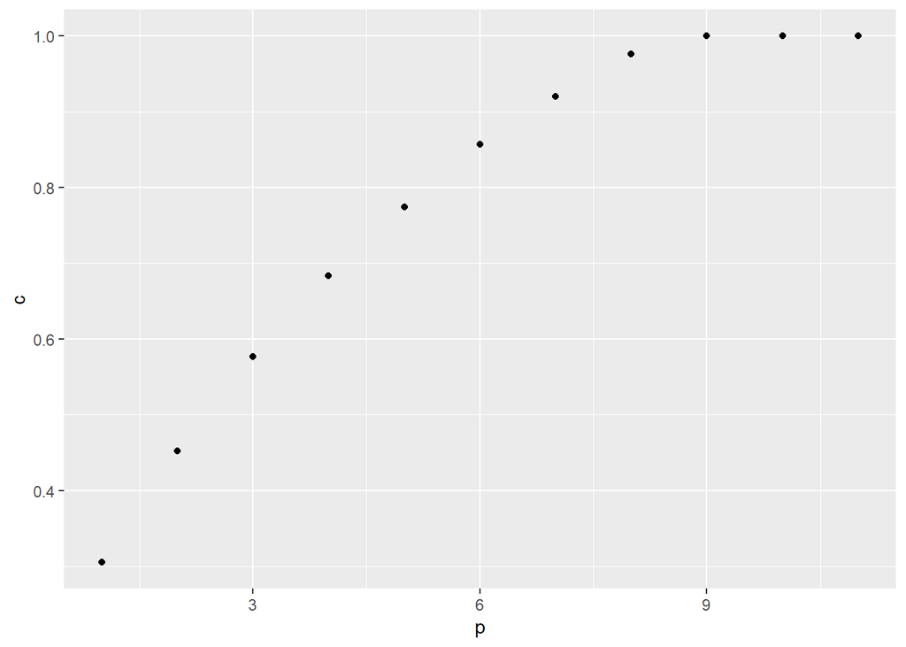

```r
# Replace NA values in each column with the column mean
df <- data.frame(lapply(df, function(x) {
  if (is.numeric(x)) {
    x[is.na(x)] <- mean(x, na.rm = TRUE)
  }
  return(x)
}))

pca.out <- prcomp(df[,-1] , scale = TRUE)
v <- pca.out$sdev^2
# round(cumsum(v/sum(v)) , 3)

pve <- v / sum(v)
ggplot(data.frame(p=1:ncol(df[,-1]),c = cumsum(pve)),mapping=aes(x=p,y=c)) +
  geom_point()
```

```r
round(pca.out$rotation[,1:10],9)
```

```
##                   PC1         PC2         PC3         PC4         PC5
## ra_x     -0.023228575 -0.54791361 -0.18777289 -0.06531615  0.47019462
## dec_x     0.218097897 -0.29333777 -0.26535392  0.20451654 -0.46442954
## parallax -0.281669118 -0.03437308  0.10769123  0.51702965  0.04210058
## pmra      0.006484531  0.37145592 -0.44810244  0.13921896 -0.24464578
## pmdec     0.066494294 -0.01344621 -0.07528116 -0.79645626 -0.10648026
## g_mag     0.531049480  0.05349696  0.09864099  0.08461523  0.03618661
## b_mag     0.531044159  0.08279277  0.08229425  0.08862316  0.10926490
## r_mag     0.526247643  0.02806875  0.11189583  0.07975161 -0.02637752
## br_col    0.096592684  0.27555951 -0.13009850  0.06011773  0.68271726
## L        -0.119440482  0.36621371  0.65062937 -0.07555960 -0.06659586
## B         0.059485310 -0.50383715  0.45497354  0.04653072 -0.07601474
##                  PC6         PC7          PC8         PC9         PC10
## ra_x      0.39710553 -0.21888429  0.045973257  0.48054802  0.000448195
## dec_x    -0.55308853 -0.08027174 -0.003939671  0.47548320 -0.001191331
## parallax  0.01945474  0.29350772  0.740284220  0.06514427  0.001298277
## pmra      0.31083887 -0.64473879  0.255012688 -0.06788806 -0.000121160
## pmdec    -0.12088601  0.07631399  0.567808165  0.03473324 -0.000251403
## g_mag     0.13555361  0.07382202  0.095592803  0.01405013 -0.265565115
## b_mag     0.06786093  0.04579658  0.103427575  0.01149162  0.802858519
## r_mag     0.19099069  0.09602982  0.087349512  0.01582365 -0.516223311
## br_col   -0.58471926 -0.23594519  0.099041688 -0.02544714 -0.135657595
## L         0.01362786 -0.28903465 -0.003180499  0.57829183 -0.000586935
## B        -0.15247260 -0.53104379  0.158518366 -0.44416383  0.000387356
```

PC Regression

```r
set.seed(120)
df.pc <- data.frame(pca.out$x,df$teff) %>% select(-PC10, -PC11)
names(df.pc) <- c("PC1","PC2","PC3","PC4","PC5","PC6","PC7","PC8","PC9","y")
summary(df.pc)
```

```
##       PC1               PC2               PC3               PC4
##  Min.   :-9.0078   Min.   :-7.6111   Min.   :-5.7251   Min.   :-6.2729
##  1st Qu.:-1.0889   1st Qu.:-1.0400   1st Qu.:-0.7933   1st Qu.:-0.6030
##  Median : 0.1273   Median : 0.0457   Median :-0.1185   Median :-0.1646
##  Mean   : 0.0000   Mean   : 0.0000   Mean   : 0.0000   Mean   : 0.0000
##  3rd Qu.: 1.2825   3rd Qu.: 0.9507   3rd Qu.: 0.6842   3rd Qu.: 0.3894
##  Max.   : 5.0578   Max.   : 6.7504   Max.   : 9.3279   Max.   :15.5322
##       PC5                PC6                PC7                PC8
##  Min.   :-3.25444   Min.   :-5.68294   Min.   :-7.05434   Min.   :-6.2280
##  1st Qu.:-0.71014   1st Qu.:-0.56563   1st Qu.:-0.50848   1st Qu.:-0.4837
##  Median :-0.07388   Median : 0.02526   Median :-0.03153   Median :-0.1204
##  Mean   : 0.00000   Mean   : 0.00000   Mean   : 0.00000   Mean   : 0.0000
##  3rd Qu.: 0.62926   3rd Qu.: 0.60921   3rd Qu.: 0.43966   3rd Qu.: 0.3754
##  Max.   : 5.11118   Max.   : 6.07322   Max.   :10.68681   Max.   : 8.2055
##       PC9                 y
##  Min.   :-1.86881   Min.   :3664
##  1st Qu.:-0.16992   1st Qu.:4911
##  Median : 0.01005   Median :5547
##  Mean   : 0.00000   Mean   :5517
##  3rd Qu.: 0.20093   3rd Qu.:6017
##  Max.   : 2.60507   Max.   :8631
```

```r
lm.out <- lm(y ~.,data=df.pc,subset=s)
lm.pred <- predict(lm.out,newdata=df.pc[-s,])
mean((lm.pred-df.pc$y[-s])^2)
```

```
## [1] 195109.8
```

Principal Components as Predictors: Using principal components can effectively reduce dimensionality while retaining significant information from the original dataset, which may help in avoiding overfitting that can occur with high-dimensional datasets.

The MSE of 195109.8 suggests that while the model captures some variance in the data, there may still be room for improvement.